File: Customizing-Travel_EDA.ipynb  
Name: Corinne Medeiros  
Date: 7/18/21  
Desc: Customizing Travel Based on User Ratings EDA  
Usage: Program imports and cleans data, and generates charts.

```python
import pandas as pd
import numpy as np

import matplotlib.pyplot as plt
import matplotlib as mpl
from matplotlib import style
import matplotlib.cm as cm

import seaborn as sns
```

# Customizing Travel Based on User Ratings

## *Exploratory Data Analysis (EDA) in Python*

### Data Source

**Travel Reviews Data Set**  
https://archive.ics.uci.edu/ml/datasets/Travel+Reviews#

This dataset from the UCI Machine Learning Repository contains one csv file with data from TripAdvisor.com reviews on destinations within East Asia. There are 980 observations, and each user has average ratings in 10 categories including art galleries, dance clubs, juice bars, restaurants, museums, resorts, parks, beaches, theaters, and religious institutions. Ratings are on a scale of Excellent (4), Very Good (3), Average (2), Poor (1), and Terrible (0).

### Loading Data

```python
# Loading user ratings data
travel_df = pd.read_csv('tripadvisor_review.csv')
```

```python
# Data summary
travel_df.info()
```

```
<class 'pandas.core.frame.DataFrame'>
RangeIndex: 980 entries, 0 to 979
Data columns (total 11 columns):
 #   Column       Non-Null Count  Dtype
---  ------       --------------  -----
 0   User ID      980 non-null    object
 1   Category 1   980 non-null    float64
 2   Category 2   980 non-null    float64
 3   Category 3   980 non-null    float64
 4   Category 4   980 non-null    float64
 5   Category 5   980 non-null    float64
 6   Category 6   980 non-null    float64
 7   Category 7   980 non-null    float64
 8   Category 8   980 non-null    float64
 9   Category 9   980 non-null    float64
 10  Category 10  980 non-null    float64
dtypes: float64(10), object(1)
memory usage: 84.3+ KB
```

```python
# Summary of variables
travel_df.describe()
```

|  | Category 1 | Category 2 | Category 3 | Category 4 | Category 5 | Category 6 | Category 7 | Category 8 | Category 9 | Category 10 |
| --- | --- | --- | --- | --- | --- | --- | --- | --- | --- | --- |
| count | 980.000000 | 980.000000 | 980.000000 | 980.000000 | 980.000000 | 980.000000 | 980.000000 | 980.000000 | 980.000000 | 980.000000 |
| mean | 0.893194 | 1.352612 | 1.013306 | 0.532500 | 0.939735 | 1.842898 | 3.180939 | 2.835061 | 1.569439 | 2.799224 |
| std | 0.326912 | 0.478280 | 0.788607 | 0.279731 | 0.437430 | 0.539538 | 0.007824 | 0.137505 | 0.364629 | 0.321380 |
| min | 0.340000 | 0.000000 | 0.130000 | 0.150000 | 0.060000 | 0.140000 | 3.160000 | 2.420000 | 0.740000 | 2.140000 |
| 25% | 0.670000 | 1.080000 | 0.270000 | 0.410000 | 0.640000 | 1.460000 | 3.180000 | 2.740000 | 1.310000 | 2.540000 |
| 50% | 0.830000 | 1.280000 | 0.820000 | 0.500000 | 0.900000 | 1.800000 | 3.180000 | 2.820000 | 1.540000 | 2.780000 |
| 75% | 1.020000 | 1.560000 | 1.572500 | 0.580000 | 1.200000 | 2.200000 | 3.180000 | 2.910000 | 1.760000 | 3.040000 |
| max | 3.220000 | 3.640000 | 3.620000 | 3.440000 | 3.300000 | 3.760000 | 3.210000 | 3.390000 | 3.170000 | 3.660000 |

```python
# Previewing data
travel_df.head(10)
```

|  | User ID | Category 1 | Category 2 | Category 3 | Category 4 | Category 5 | Category 6 | Category 7 | Category 8 | Category 9 | Category 10 |
| --- | --- | --- | --- | --- | --- | --- | --- | --- | --- | --- | --- |
| 0 | User 1 | 0.93 | 1.80 | 2.29 | 0.62 | 0.80 | 2.42 | 3.19 | 2.79 | 1.82 | 2.42 |
| 1 | User 2 | 1.02 | 2.20 | 2.66 | 0.64 | 1.42 | 3.18 | 3.21 | 2.63 | 1.86 | 2.32 |
| 2 | User 3 | 1.22 | 0.80 | 0.54 | 0.53 | 0.24 | 1.54 | 3.18 | 2.80 | 1.31 | 2.50 |
| 3 | User 4 | 0.45 | 1.80 | 0.29 | 0.57 | 0.46 | 1.52 | 3.18 | 2.96 | 1.57 | 2.86 |
| 4 | User 5 | 0.51 | 1.20 | 1.18 | 0.57 | 1.54 | 2.02 | 3.18 | 2.78 | 1.18 | 2.54 |
| 5 | User 6 | 0.99 | 1.28 | 0.72 | 0.27 | 0.74 | 1.26 | 3.17 | 2.89 | 1.66 | 3.66 |
| 6 | User 7 | 0.90 | 1.36 | 0.26 | 0.32 | 0.86 | 1.58 | 3.17 | 2.66 | 1.22 | 3.22 |
| 7 | User 8 | 0.74 | 1.40 | 0.22 | 0.41 | 0.82 | 1.50 | 3.17 | 2.81 | 1.54 | 2.88 |
| 8 | User 9 | 1.12 | 1.76 | 1.04 | 0.64 | 0.82 | 2.14 | 3.18 | 2.79 | 1.41 | 2.54 |
| 9 | User 10 | 0.70 | 1.36 | 0.22 | 0.26 | 1.50 | 1.54 | 3.17 | 2.82 | 2.24 | 3.12 |

### Cleaning data

```python
# Setting User ID as index
travel_df = travel_df.set_index('User ID')
```

I'll use the following information from the source to change the column names to be more descriptive.

**Attribute information:**

Attribute 1 : Unique user id  
Attribute 2 : Average user feedback on art galleries  
Attribute 3 : Average user feedback on dance clubs  
Attribute 4 : Average user feedback on juice bars  
Attribute 5 : Average user feedback on restaurants  
Attribute 6 : Average user feedback on museums  
Attribute 7 : Average user feedback on resorts  
Attribute 8 : Average user feedback on parks/picnic spots  
Attribute 9 : Average user feedback on beaches  
Attribute 10 : Average user feedback on theaters  
Attribute 11 : Average user feedback on religious institutions

```python
# Renaming columns
travel_df.rename(columns = {'Category 1':'Art Galleries',
                            'Category 2':'Dance Clubs',
                            'Category 3':'Juice Bars',
                            'Category 4':'Restaurants',
                            'Category 5':'Museums',
                            'Category 6':'Resorts',
                            'Category 7':'Parks & Picnic Spots',
                            'Category 8':'Beaches',
                            'Category 9':'Theaters',
                            'Category 10':'Religious Institutions'}, inplace=True)
```

```python
travel_df.head(10)
```

| User ID | Art Galleries | Dance Clubs | Juice Bars | Restaurants | Museums | Resorts | Parks & Picnic Spots | Beaches | Theaters | Religious Institutions |
| --- | --- | --- | --- | --- | --- | --- | --- | --- | --- | --- |
| User 1 | 0.93 | 1.80 | 2.29 | 0.62 | 0.80 | 2.42 | 3.19 | 2.79 | 1.82 | 2.42 |
| User 2 | 1.02 | 2.20 | 2.66 | 0.64 | 1.42 | 3.18 | 3.21 | 2.63 | 1.86 | 2.32 |
| User 3 | 1.22 | 0.80 | 0.54 | 0.53 | 0.24 | 1.54 | 3.18 | 2.80 | 1.31 | 2.50 |
| User 4 | 0.45 | 1.80 | 0.29 | 0.57 | 0.46 | 1.52 | 3.18 | 2.96 | 1.57 | 2.86 |
| User 5 | 0.51 | 1.20 | 1.18 | 0.57 | 1.54 | 2.02 | 3.18 | 2.78 | 1.18 | 2.54 |
| User 6 | 0.99 | 1.28 | 0.72 | 0.27 | 0.74 | 1.26 | 3.17 | 2.89 | 1.66 | 3.66 |
| User 7 | 0.90 | 1.36 | 0.26 | 0.32 | 0.86 | 1.58 | 3.17 | 2.66 | 1.22 | 3.22 |
| User 8 | 0.74 | 1.40 | 0.22 | 0.41 | 0.82 | 1.50 | 3.17 | 2.81 | 1.54 | 2.88 |
| User 9 | 1.12 | 1.76 | 1.04 | 0.64 | 0.82 | 2.14 | 3.18 | 2.79 | 1.41 | 2.54 |
| User 10 | 0.70 | 1.36 | 0.22 | 0.26 | 1.50 | 1.54 | 3.17 | 2.82 | 2.24 | 3.12 |

```python
# Checking for missing data
travel_df.isna().sum()
```

```
Art Galleries             0
Dance Clubs               0
Juice Bars                0
Restaurants               0
Museums                   0
Resorts                   0
Parks & Picnic Spots      0
Beaches                   0
Theaters                  0
Religious Institutions    0
dtype: int64
```

```python
# Removing index title
travel_df.index.name = ""
```

```python
# Summary of variables
travel_df.describe()
```

|  | Art Galleries | Dance Clubs | Juice Bars | Restaurants | Museums | Resorts | Parks & Picnic Spots | Beaches | Theaters | Religious Institutions |
| --- | --- | --- | --- | --- | --- | --- | --- | --- | --- | --- |
| count | 980.000000 | 980.000000 | 980.000000 | 980.000000 | 980.000000 | 980.000000 | 980.000000 | 980.000000 | 980.000000 | 980.000000 |
| mean | 0.893194 | 1.352612 | 1.013306 | 0.532500 | 0.939735 | 1.842898 | 3.180939 | 2.835061 | 1.569439 | 2.799224 |
| std | 0.326912 | 0.478280 | 0.788607 | 0.279731 | 0.437430 | 0.539538 | 0.007824 | 0.137505 | 0.364629 | 0.321380 |
| min | 0.340000 | 0.000000 | 0.130000 | 0.150000 | 0.060000 | 0.140000 | 3.160000 | 2.420000 | 0.740000 | 2.140000 |
| 25% | 0.670000 | 1.080000 | 0.270000 | 0.410000 | 0.640000 | 1.460000 | 3.180000 | 2.740000 | 1.310000 | 2.540000 |
| 50% | 0.830000 | 1.280000 | 0.820000 | 0.500000 | 0.900000 | 1.800000 | 3.180000 | 2.820000 | 1.540000 | 2.780000 |
| 75% | 1.020000 | 1.560000 | 1.572500 | 0.580000 | 1.200000 | 2.200000 | 3.180000 | 2.910000 | 1.760000 | 3.040000 |
| max | 3.220000 | 3.640000 | 3.620000 | 3.440000 | 3.300000 | 3.760000 | 3.210000 | 3.390000 | 3.170000 | 3.660000 |

### Data Visualization

```python
# Creating subset of users with highest ratings for Dance Clubs
travel_df_dance = travel_df[travel_df["Dance Clubs"] > 2.9]

travel_df_dance.info()
```

```
<class 'pandas.core.frame.DataFrame'>
Index: 16 entries, User 12 to User 883
Data columns (total 10 columns):
 #   Column                  Non-Null Count  Dtype
---  ------                  --------------  -----
 0   Art Galleries           16 non-null     float64
 1   Dance Clubs             16 non-null     float64
 2   Juice Bars              16 non-null     float64
 3   Restaurants             16 non-null     float64
 4   Museums                 16 non-null     float64
 5   Resorts                 16 non-null     float64
 6   Parks & Picnic Spots    16 non-null     float64
 7   Beaches                 16 non-null     float64
 8   Theaters                16 non-null     float64
 9   Religious Institutions  16 non-null     float64
dtypes: float64(10)
memory usage: 1.4+ KB
```

```python
travel_df_dance
```

|  | Art Galleries | Dance Clubs | Juice Bars | Restaurants | Museums | Resorts | Parks & Picnic Spots | Beaches | Theaters | Religious Institutions |
| --- | --- | --- | --- | --- | --- | --- | --- | --- | --- | --- |
| User 12 | 0.96 | 2.96 | 0.29 | 0.38 | 0.88 | 2.08 | 3.17 | 2.93 | 1.66 | 3.42 |
| User 49 | 0.45 | 2.96 | 0.26 | 0.40 | 0.56 | 1.68 | 3.18 | 2.90 | 1.44 | 2.72 |
| User 76 | 0.99 | 2.96 | 1.71 | 0.45 | 1.36 | 1.96 | 3.19 | 2.69 | 1.38 | 2.32 |
| User 146 | 0.96 | 2.96 | 0.29 | 0.38 | 0.88 | 2.08 | 3.17 | 2.93 | 1.66 | 3.42 |
| User 229 | 0.54 | 2.96 | 0.58 | 0.57 | 0.78 | 1.70 | 3.18 | 2.91 | 1.28 | 3.30 |
| User 378 | 0.70 | 2.96 | 0.43 | 0.50 | 1.12 | 1.92 | 3.17 | 2.94 | 1.31 | 3.26 |
| User 423 | 0.51 | 2.92 | 0.16 | 1.58 | 1.54 | 2.00 | 3.18 | 2.74 | 0.96 | 2.46 |
| User 484 | 0.58 | 2.96 | 1.90 | 0.53 | 1.44 | 2.24 | 3.19 | 3.18 | 2.18 | 2.70 |
| User 546 | 0.86 | 2.96 | 0.24 | 0.41 | 0.72 | 1.62 | 3.18 | 2.98 | 1.54 | 2.98 |
| User 600 | 1.12 | 2.96 | 0.16 | 0.50 | 0.48 | 1.76 | 3.18 | 2.78 | 1.76 | 2.72 |
| User 609 | 1.06 | 3.12 | 1.58 | 0.48 | 0.56 | 3.34 | 3.18 | 2.67 | 1.76 | 2.94 |
| User 642 | 0.54 | 2.96 | 0.38 | 0.61 | 1.62 | 2.42 | 3.18 | 3.22 | 2.43 | 2.80 |
| User 703 | 1.09 | 2.96 | 1.79 | 0.79 | 1.18 | 2.00 | 3.19 | 2.66 | 2.59 | 2.46 |
| User 729 | 0.86 | 2.96 | 0.21 | 1.98 | 0.90 | 1.62 | 3.18 | 2.70 | 1.47 | 2.46 |
| User 813 | 0.96 | 3.64 | 1.31 | 0.39 | 1.34 | 2.66 | 3.18 | 3.02 | 1.57 | 3.12 |
| User 883 | 0.96 | 2.96 | 0.74 | 0.47 | 0.96 | 2.12 | 3.18 | 2.86 | 1.44 | 2.64 |

```python
# Sorting by Dance Clubs ratings
travel_df_dance = travel_df_dance.sort_values(by=["Dance Clubs"], ascending=False)
```

### Heatmaps

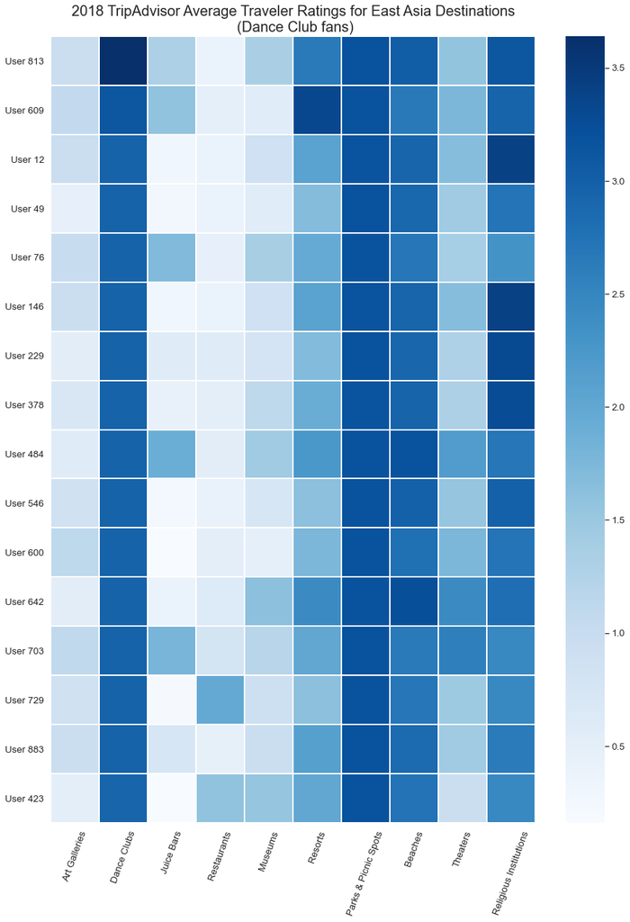

```python
# Setting font
sns.set(font_scale=1.2)

# Heatmap
ax = sns.heatmap(travel_df_dance, cmap=plt.cm.Blues, linewidths=.1, xticklabels=True, yticklabels=True)
fig = ax.get_figure()
fig.set_size_inches(15, 20)

# Labels, rotation
plt.xticks(rotation=70)
ax.set_title('2018 TripAdvisor Average Traveler Ratings for East Asia Destinations\n (Dance Club fans)', fontsize =20)
```

```python
# Creating subset of users with highest ratings for Restaurants
travel_df_food = travel_df[travel_df["Restaurants"] > 2]

travel_df_food.info()
```

```
<class 'pandas.core.frame.DataFrame'>
Index: 9 entries, User 248 to User 830
Data columns (total 10 columns):
 #   Column                  Non-Null Count  Dtype
---  ------                  --------------  -----
 0   Art Galleries           9 non-null      float64
 1   Dance Clubs             9 non-null      float64
 2   Juice Bars              9 non-null      float64
 3   Restaurants             9 non-null      float64
 4   Museums                 9 non-null      float64
 5   Resorts                 9 non-null      float64
 6   Parks & Picnic Spots    9 non-null      float64
 7   Beaches                 9 non-null      float64
 8   Theaters                9 non-null      float64
 9   Religious Institutions  9 non-null      float64
dtypes: float64(10)
memory usage: 792.0+ bytes
```

#### *Observations so far*

My initial conclusion was that dance club fans also tend to enjoy parks and beaches, but looking back at the dataframe summary, we can see that all users rated beaches and parks very highly. It might be helpful to look at restaurants and art galleries, which were both rated low by dance club fans.

```python
travel_df_food
```

|  | Art Galleries | Dance Clubs | Juice Bars | Restaurants | Museums | Resorts | Parks & Picnic Spots | Beaches | Theaters | Religious Institutions |
| --- | --- | --- | --- | --- | --- | --- | --- | --- | --- | --- |
| User 248 | 1.50 | 1.96 | 2.08 | 2.73 | 1.12 | 2.94 | 3.20 | 2.63 | 1.63 | 2.46 |
| User 275 | 1.15 | 1.76 | 1.33 | 2.91 | 0.74 | 1.90 | 3.18 | 2.78 | 1.38 | 2.72 |
| User 287 | 0.93 | 1.76 | 0.58 | 2.25 | 2.00 | 2.44 | 3.18 | 2.67 | 1.22 | 2.42 |
| User 438 | 1.06 | 1.08 | 0.13 | 2.11 | 0.32 | 2.50 | 3.18 | 2.78 | 1.98 | 2.50 |
| User 593 | 0.70 | 2.28 | 0.22 | 2.38 | 0.38 | 1.28 | 3.18 | 2.81 | 1.38 | 2.66 |
| User 602 | 1.15 | 0.80 | 0.26 | 3.10 | 0.64 | 1.86 | 3.18 | 2.77 | 2.02 | 2.62 |
| User 667 | 1.95 | 1.52 | 1.94 | 3.44 | 0.64 | 2.94 | 3.20 | 2.62 | 1.54 | 2.46 |
| User 695 | 0.96 | 1.80 | 0.56 | 2.25 | 2.02 | 2.40 | 3.18 | 2.69 | 1.25 | 2.42 |
| User 830 | 0.93 | 1.76 | 0.58 | 2.29 | 2.00 | 2.42 | 3.18 | 2.69 | 1.31 | 2.42 |

```python
# Sorting by Restaurants ratings
travel_df_food = travel_df_food.sort_values(by=["Restaurants"], ascending=False)
```

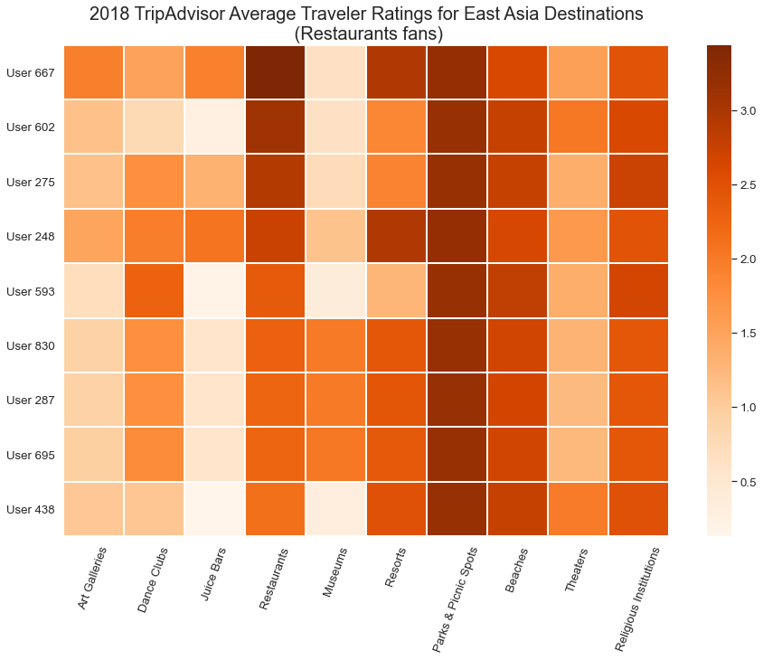

```python
# Setting font
sns.set(font_scale=1.2)

# Heatmap
ax = sns.heatmap(travel_df_food, cmap=plt.cm.Oranges, linewidths=.1, xticklabels=True, yticklabels=True)
fig = ax.get_figure()
fig.set_size_inches(15, 10)

# Labels, rotation
plt.xticks(rotation=70)
ax.set_title('2018 TripAdvisor Average Traveler Ratings for East Asia Destinations\n (Restaurants fans)', fontsize =20)
```

At this point I'm curious about the general relationships of ratings across all categories, so I'm going to create a pairs plot and also explore some visualizations in Tableau.

### Pairs Plot

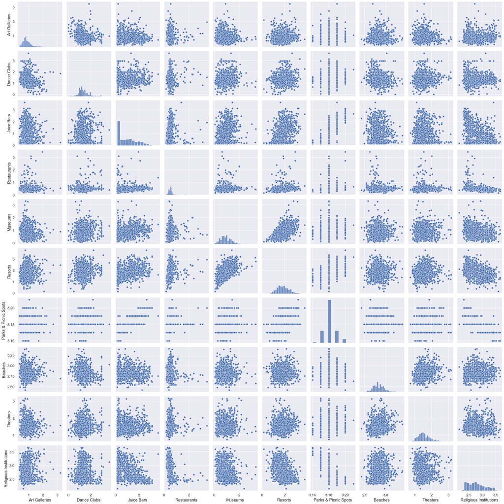

```python
# Creating Pairplot
sns.pairplot(travel_df)
```

This pairs plot helps reveal patterns and trends across all the data. We can quickly see the distributions of variables and the relationships between variables. There doesn't appear to be many strong relationships, but Museum and Resort ratings have a slight positive correlation.

With a better understanding of the data, I'll save the cleaned dataframe and move into R for clustering analysis.

```python
# Saving dataframe as csv file
travel_df.to_csv('travel_df.csv')
```